# The Economic Order Quantity, and What a Wrong One Costs

Manuel D. Rossetti, PhD P.E.

## Agenda

- The classical economic order quantity, worked end to end on one item
- When to place the order, and the case where the obvious answer is wrong
- What a *wrong* order quantity costs, derived and then priced
- Why that cost licenses rounding, case quantities and delivery schedules

Same assumptions as last session: demand known and constant, replenishment instantaneous, no shortages permitted.

## Where We Left Off

Last session the general cycle reduced to four classical models. Today we work inside the simplest. Its cost rate has three terms:

$$\mathit{TC}(Q) = \underbrace{\frac{k\lambda}{Q}}_{\text{ordering}}
+ \underbrace{c\lambda}_{\text{purchase}}
+ \underbrace{\frac{hQ}{2}}_{\text{holding}}$$

$$\begin{aligned}
\frac{d\,\mathit{TC}}{dQ} &= -\frac{k\lambda}{Q^{2}} + \frac{h}{2} = 0
&&\text{the purchase term has no } Q \text{ in it}\\
Q^{*} &= \sqrt{\frac{2k\lambda}{h}}
&&\text{solve for } Q\\
\mathit{TC}^{*} &= \sqrt{2k\lambda h} + c\lambda
&&\text{substitute back}
\end{aligned}$$

At $Q^{*}$ the **ordering and holding terms are equal**. If they are not, $Q$ is not optimal.

## The Trade-Off, Drawn

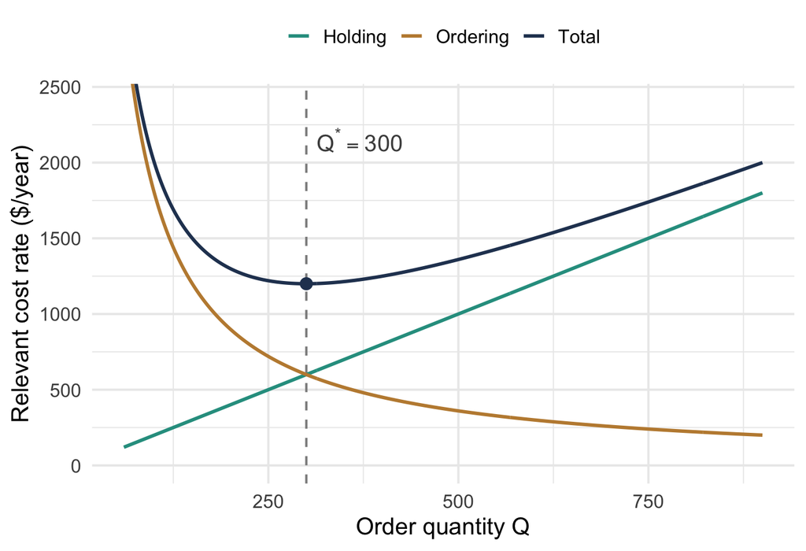

$\lambda = 2400$ per year, $k = \$75$, $h = \$4$.

**Ordering** falls steeply: a small order means many orders a year.

**Holding** rises in a straight line, since average stock is $Q/2$.

They **cross at $Q^{*} = 300$**, the equal-terms property made visible.

Notice that the total is **flat** near its minimum. That flatness is the second half of today.

## The Item

A product is demanded at $\lambda = 220$ units per year and costs $c = \$1{,}200$ per unit. An order costs $k = \$800$, and the carrying charge is $i = 0.18$ per year. No shortages are allowed.

| Question | Answer |
| --- | --- |
| *What is stocked?* | One item, bought from an outside supplier |
| *What is the demand process?* | Constant at 220 units per year, known in advance |
| *When is inventory reviewed?* | Continuously |
| *What triggers replenishment, and how much?* | The shelf reaching zero; $Q$ units, which is the decision |
| *What happens to unmet demand?* | None occurs; shortages are not allowed |
| *What costs are incurred, and when?* | $k = \$800$ per order; $i = 0.18$ per year on the value held |

## The EOQ, Worked End to End

$$\begin{aligned}
h &= ic = (0.18)(1200) = \$216 \text{ per unit per year}\\[4pt]
Q^{*} &= \sqrt{\frac{2k\lambda}{h}}
= \sqrt{\frac{2(800)(220)}{216}}
= \sqrt{1629.63} = 40.37 \text{ units}\\[4pt]
T^{*} &= \frac{Q^{*}}{\lambda} = \frac{40.37}{220} = 0.1835 \text{ year}
= 66.98 \text{ days}\\[4pt]
\sqrt{2k\lambda h} &= \sqrt{2(800)(220)(216)} = \$8{,}719.63\\[4pt]
\mathit{TC}^{*} &= \$8{,}719.63 + (1200)(220) = \$272{,}719.63
\end{aligned}$$

*The check.* The two relevant terms must be equal at $Q^{*}$.

$$\begin{aligned}
\frac{k\lambda}{Q^{*}} &= \frac{(800)(220)}{40.37} = \$4{,}359.82\\[4pt]
\frac{hQ^{*}}{2} &= \frac{(216)(40.37)}{2} = \$4{,}359.82
\end{aligned}$$

Equal, so $Q^{*}$ is optimal. Perform this check every time; unequal halves mean $Q$ is not optimal.

## What the Decision Can Move

| Component | Amount | Share |
| --- | --- | --- |
| Purchase, $c\lambda$ | $264,000.00 | 96.8% |
| Ordering, $k\lambda/Q^{*}$ | $4,359.82 | 1.6% |
| Holding, $hQ^{*}/2$ | $4,359.82 | 1.6% |
| **Total** | **$272,719.63** |  |

Notice that the purchase term is 97% of the total and is untouched by the decision: we buy 220 units a year whatever $Q$ is.

The $8,719.63 is the **entire quantity the lot sizing decision can influence**. Comparing policies on total cost, with the purchase term in, makes every alternative look nearly identical.

## When Do We Order?

With demand and lead time both known, the timing is exact: the order arrives at the instant stock would otherwise reach $-\hat{B}$.

- Let $L$ represent the replenishment **lead time**, known and constant.
- Let $r$ represent the **reorder point**, the inventory *position* at which the order is placed.

When $L \le T$, demand over the lead time is $\lambda L$, so

$$r = \lambda L - \hat{B}, \qquad\text{and with no backorders}\qquad r = \lambda L$$

For the item, with a seven day lead time: $r = 220\left(\dfrac{7}{365}\right) = 4.22$ units. Seven days is well under the 67 day cycle.

$r$ is a level of inventory **position**, not of stock on hand. A rule that triggers on the shelf alone orders again, and again, while the first order is still in transit.

## A Lead Time Longer Than a Cycle

When $L > T$, orders are already outstanding when the next one is placed. They cover whole cycles of the lead time, and only the remainder is uncovered:

$$\begin{aligned}
&\left\lfloor L/T \right\rfloor
&&\text{whole cycles inside the lead time, each already ordered}\\
&L - \left\lfloor L/T \right\rfloor T
&&\text{the part of the lead time not yet covered}\\
r &= \left(L - \left\lfloor \frac{L}{T} \right\rfloor T\right)\lambda - \hat{B}
&&\text{demand over that part}
\end{aligned}$$

*The worksheet’s item.* $\lambda = 100$ per month, $T^{*} = 1.5492$ months, and the supplier quotes $L = 4$ months. Why can $r = \lambda L = 400$ not be right?

It is more than twice the order quantity. Instead:

$$\left\lfloor \frac{4}{1.5492} \right\rfloor = 2,
\qquad 4 - 2(1.5492) = 0.9016 \text{ month},
\qquad r = 100(0.9016) = 90.16 \text{ units}$$

## The Reorder Point Against the Lead Time

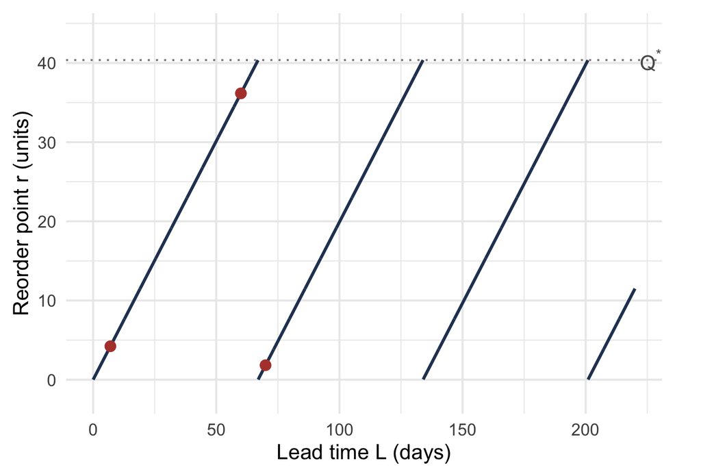

The item of today’s example, $T^{*} = 66.98$ days.

| $L$ (days) | $\lfloor L/T \rfloor$ | $r$ |
| --- | --- | --- |
| 7 | 0 | 4.22 |
| 60 | 0 | 36.16 |
| 70 | 1 | **1.82** |

Notice that ten more days of lead time drops $r$ from 36.16 to 1.82. **The reorder point is not monotone in the lead time.**

## Where the Penalty Formula Comes From

No warehouse orders 40.37 of anything. **How much is lost by not ordering $Q^{*}$?** Let $C(Q) = k\lambda/Q + hQ/2$ represent the relevant cost rate and $C^{*} = C(Q^{*})$ its minimum.

$$\begin{aligned}
Q^{*2} &= \frac{2k\lambda}{h}
&&\text{square the EOQ}\\
k\lambda &= \frac{hQ^{*2}}{2}
&&\text{solve for } k\lambda\\
C(Q) &= \frac{hQ^{*2}}{2Q} + \frac{hQ}{2}
= \frac{h}{2}\left(\frac{Q^{*2}}{Q} + Q\right)
&&\text{substitute for } k\lambda\\
C^{*} &= \frac{h}{2}\left(Q^{*} + Q^{*}\right) = hQ^{*}
&&\text{set } Q = Q^{*}\\
\frac{C(Q)}{C^{*}} &= \frac{1}{2Q^{*}}\left(\frac{Q^{*2}}{Q} + Q\right)
= \frac{1}{2}\left(\frac{Q}{Q^{*}} + \frac{Q^{*}}{Q}\right)
&&\text{divide}
\end{aligned}$$

Notice that $k$, $\lambda$, $h$ and $c$ have all cancelled. **The penalty depends only on the ratio $Q/Q^{*}$.**

## Wrong by a Fifth, Wrong by Half

Order 50% too much, $Q/Q^{*} = 3/2$:

$$\frac{C}{C^{*}} = \frac{1}{2}\left(\frac{3}{2} + \frac{2}{3}\right)
= \frac{1}{2}\left(\frac{9+4}{6}\right) = \frac{13}{12} = 1.083$$

That is 8.3% of the relevant cost, about **$727 a year** for today’s item ($0.0833 \times \$8{,}719.63$).

The formula is symmetric in $Q/Q^{*}$ and its reciprocal, so half and double cost the same.

| $Q/Q^{*}$ | $C/C^{*}$ | Penalty | Today’s item |
| --- | --- | --- | --- |
| 1/2 | 1.2500 | 25.0% | $2,179.91 |
| 4/5 | 1.0250 | 2.5% | $217.99 |
| 6/5 | 1.0167 | 1.7% | $145.33 |
| 3/2 | 1.0833 | 8.3% | $726.64 |
| 2 | 1.2500 | 25.0% | $2,179.91 |

Being wrong by half is expensive; being wrong by a fifth is not.

## Rounding Today’s Item

$Q^{*} = 40.37$ units, relevant cost $8,719.63 a year. Three ways a warehouse would actually order it:

| Order | $Q$ | $Q/Q^{*}$ | $C/C^{*}$ | Extra per year |
| --- | --- | --- | --- | --- |
| Three cases of 12 | 36 | 0.8918 | 1.0066 | $57.26 |
| Four cases of 12 | 48 | 1.1890 | 1.0150 | $131.03 |
| Every ten weeks on the truck, $220(10/52)$ | 42.31 | 1.0480 | 1.0011 | **$9.60** |

Notice the last row. Ordering every ten weeks costs **0.11%**, nine dollars and sixty cents a year, to put the item on a truck that was leaving anyway.

## What Flatness Licenses

All of these move $Q$ off its optimum, and all of them are nearly free:

- round to a whole number, a case, a pallet;
- fit a delivery schedule you already run;
- put several items on one shared cycle;
- round a cycle length to a power of two.

**And what it does not license**

Flatness is a statement about the **relevant** cost, which excludes the purchase term.

Introduce a **quantity discount** and the purchase term stops being constant. It becomes the thing the decision moves, it is far larger than the relevant cost, and it is **discontinuous** at each price break.

## What We Did Today

**The EOQ worked end to end.** $h = ic$, then $Q^{*}$, then $T^{*}$, then $\mathit{TC}^{*}$, then the equal-halves check.

**The purchase term dominates the total and is irrelevant to the decision.** 97% of $272,719.63 could not be moved by any choice of $Q$.

**The reorder point reads the position, not the shelf**, and it is **not monotone** in the lead time. $r = \lambda L$ is wrong past the first cycle.

**The penalty depends only on $Q/Q^{*}$.** Wrong by a fifth costs about 2%; wrong by half costs 25%.

## For Next Time

**Read before next session:** *Quantity Discounts*, and *Performance Measures for the Cycle*.

Today’s material was *The Classical Economic Order Quantity*, *Lead Time and the Reorder Point* and *Sensitivity of the Order Quantity*.

Next session:

- All-units discounts, where the whole order reprices at a break, and why the break quantities themselves become candidates
- Incremental discounts, where only the units above a break reprice, and why they encourage **larger** orders
- The service measures the general cycle delivers, which we get for nothing from the four segments

The flat cost curve does **not** survive a price schedule. Come prepared to stop trusting it.

⌂ Index